# Exploring the Link Between Household and Climate Change Factors and Educational Achievement in Rural Pakistan: A PCA and Logistic Regression Study

Ali Abid

2024-12-03

# 1 Introduction and Situational Context

Despite being the fifth most populous country in the world, Pakistan is only able to spend as much as 1.7 percent of its GDP on education (Abbasi, 2023). The tumultuous domestic political climate, in conjunction with the global geopolitical landscape, has undeniably resulted in a series of macroeconomic crises within the nation. These crises have unfortunately led to widespread inflation, a rise in poverty, and a profound literacy crisis that poses significant challenges for future generations. A sizable children population (around 26 million) remains out of school (Haider, 2024) which can have devastating impact on the opportunities of the country to grow out of these crises.

# 2 Purpose

The purpose of this research project is to understand the the factors that influence students’ general knowledge by utilizing principal component analysis (PCA) to reduce the dataset into key components.

The dataset used in this analysis is the ASER 2023 rural dataset which is a household survey conducted in Pakistan to assess the learning levels of children in the country. The dataset contains information on the academic outcomes including whether a student exhibited general knowledge while being surveyed, the said students’ household characteristics, and the impact of climate change as reported by their households. The analysis will focus on the factors that contribute to the general knowledge of students in Pakistan and will use logistic regression to predict the outcome in a probabilistic form based on these predictors.

# 3 Data Description

**Predictor Variables**:

**Outcome Variables**:

- GeneralKnowledge: Whether the student exhibited general knowledge or not while tested by the ASER data collection team.
  - 1. Yes 0. No

# 4 Research Question

Can student’s household characteristics, and climate-change factors affecting the student’s household be combined into principal components to identify underlying factors, and how well do these factors predict a student’s general knowledge level?

# 5 Analysis

```r
rm(list=ls(all=TRUE))
```

## 5.1 Required Libraries

```r
library(tidyverse)
library(readr)
library(caret)
library(psych)
library(factoextra)
```

## 5.2 Load the data

The two distinct datasets are loaded into R. The first dataset contains the child-level data, while the second dataset contains the household-level data. The two datasets are merged on the *HouseholdId* column by first renaming the variable to *HHID* which is unique to both the datasets to create a single dataset for analysis.

```r
# Load the data
aser_child <- read_csv("ITAASER2023Child.csv")
aser_household <- read_csv("ITAASER2023Household.csv") %>%
  rename(HHID = HouseholdId) # Renaming the HouseholdId column to HHID for merging with the Child Dataset
```

## 5.3 Data Wrangling

The two datasets are merged on the HHID column to create a single dataset *aser_child_household_data* for analysis. The variables of interest as discussed in the section of predictor variables and outcome variable are selected and renamed for clarity.

```r
# Merging the two datasets
aser_child_household_data <- aser_child %>%
  left_join(aser_household, by = "HHID")

aser_child_household_data <- aser_child_household_data %>%
  select(
    # Household Characteristics
    HouseholdCounter, EarningMembers, Car, MotorCycle,

    # Time to school
    TravelTime,

    # Climate Change Impact
    ClimateChange, FloodImpacted, EarningImpacted, PsychologicalImpacted, SchoolingAffected, MigrantIDP,

    # Child Characteristics - GeneralKnowledge
    C27
  ) %>%
  rename(

    # Child Characteristics - GeneralKnowledge - whether the child exhibits GK or not
    GeneralKnolwedge = C27

  )
```

## 5.4 Data Cleaning

The dataset is cleaned by removing rows with missing values and changing column types to numeric for further analysis.

```r
# Removing the rows with missing values
aser_child_household_tib <- aser_child_household_data %>%
  na.omit() %>% #get rid of rows with NAs
  mutate_at(c(1:12),as.numeric) #change all columns to numeric
  #mutate(GeneralKnolwedge = as.factor(GeneralKnolwedge))  #change GK Score to factor
  #mutate_at(c(1:12), ~(scale(.) %>% as.vector))
  #scale all variables so mean is zero and values are standardized to SD from zero
  #as.vector ensures columns are vectors

library(psych)

psych::describe(aser_child_household_tib) #gives you a lot of descriptives quickly
```

```
##                       vars    n    mean        sd median trimmed  mad min
## HouseholdCounter         1 2378 3651.27 126147.96     11   10.50 7.41   0
## EarningMembers           2 2378   21.78    535.60      1    1.03 1.48   0
## Car                      3 2378    0.79      0.92      1    0.71 0.00   0
## MotorCycle               4 2378    0.89      0.57      1    0.86 0.00   0
## TravelTime               5 2378    1.52      0.70      1    1.40 0.00   1
## ClimateChange            6 2378    2.00      0.81      2    2.00 1.48   1
## FloodImpacted            7 2378    2.56      0.73      3    2.70 0.00   1
## EarningImpacted          8 2378    4.06      1.40      5    4.32 0.00   1
## PsychologicalImpacted    9 2378    3.30      1.07      4    3.50 0.00   1
## SchoolingAffected       10 2378    3.41      1.00      4    3.62 0.00   1
## MigrantIDP              11 2378    0.04      0.19      0    0.00 0.00   0
## GeneralKnolwedge        12 2378    0.49      0.50      0    0.49 0.00   0
##                           max   range  skew kurtosis      se
## HouseholdCounter      5789321 5789321 42.20  1882.46 2586.87
## EarningMembers          15000   15000 27.63   768.76   10.98
## Car                         9       9  4.91    37.32    0.02
## MotorCycle                  5       5  0.49     2.91    0.01
## TravelTime                  3       2  0.98    -0.35    0.01
## ClimateChange               3       2  0.00    -1.49    0.02
## FloodImpacted               3       2 -1.31     0.14    0.01
## EarningImpacted             5       4 -1.15    -0.17    0.03
## PsychologicalImpacted       4       3 -1.13    -0.32    0.02
## SchoolingAffected           4       3 -1.44     0.61    0.02
## MigrantIDP                  1       1  4.72    20.32    0.00
## GeneralKnolwedge            1       1  0.02    -2.00    0.01
```

```r
# There seems to be an outlier value in HouseholdCounter, which needs investigation.
```

The boxplot is used to identify and remove an outlier value in the *HouseholdCounter* variable.

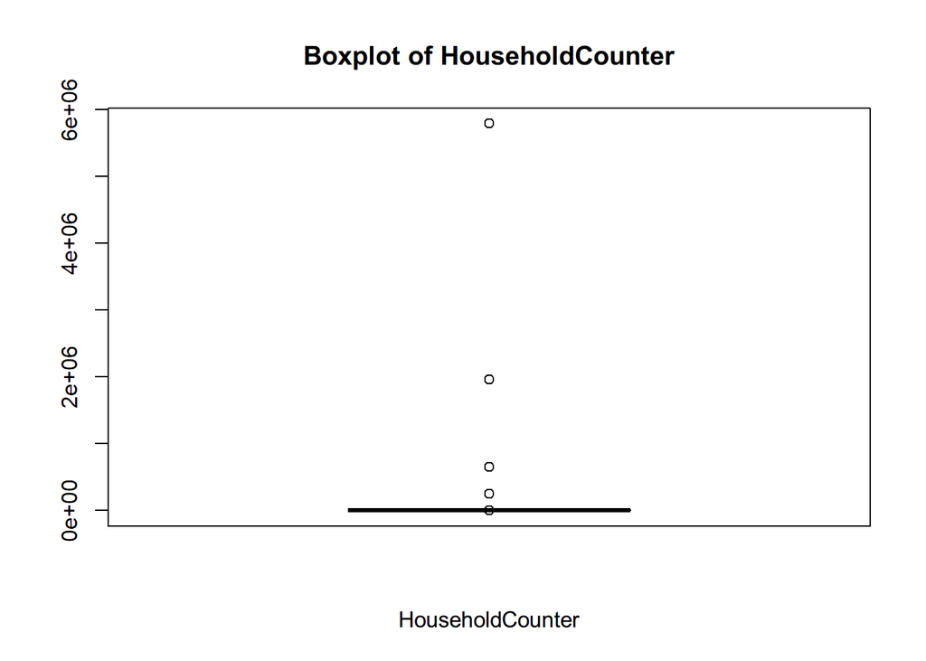

```r
boxplot(aser_child_household_tib$HouseholdCounter,
        main = "Boxplot of HouseholdCounter",
        xlab = "HouseholdCounter")
```

```r
# Let's just try to find out which is the outlier value

max(aser_child_household_tib$HouseholdCounter)
```

```
## [1] 5789321
```

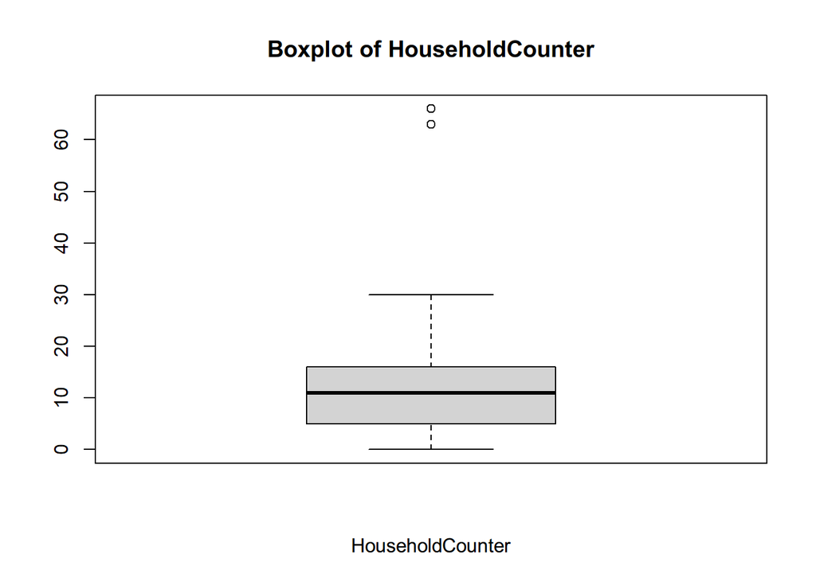

```r
# There is an outlier value in HouseholdCounter, which is 5789321. We will remove this row.

aser_child_household_tib <- aser_child_household_tib %>%
  filter(HouseholdCounter < 100)

# Checking the boxplot again to see if the outlier has been removed

boxplot(aser_child_household_tib$HouseholdCounter,
        main = "Boxplot of HouseholdCounter",
        xlab = "HouseholdCounter")
```

## 5.5 STEP 1: Correlations for Strong Multicollinearity

The correlation matrix is used to identify variables with strong multicollinearity (r>0.9) to ensure that the components accurately represent the variance in the data without redundancy.

```r
# PCA requires the removal of variables with strong multicollinearity (r>0.9) to ensure that the components accurately represent the variance in the data without redundancy.

aser_child_household_tib_excluded <- aser_child_household_tib[, -12] # Excluding the GeneralKnowledge variable as it is the outcome variable

corr_aser_pca <- cor(aser_child_household_tib_excluded)

corr_aser_pca
```

```
##                       HouseholdCounter EarningMembers          Car  MotorCycle
## HouseholdCounter           1.000000000   -0.017261914  0.085308876  0.06665192
## EarningMembers            -0.017261914    1.000000000  0.009557159  0.07543932
## Car                        0.085308876    0.009557159  1.000000000  0.38640268
## MotorCycle                 0.066651920    0.075439321  0.386402682  1.00000000
## TravelTime                 0.076883764    0.031267210  0.120566064  0.13990614
## ClimateChange              0.058505703   -0.039697296  0.042269546  0.01899966
## FloodImpacted              0.059498928    0.023669087  0.135088357  0.24800475
## EarningImpacted            0.027323823   -0.074970812  0.143746094  0.24003726
## PsychologicalImpacted      0.045746481    0.025524851  0.149841450  0.24096941
## SchoolingAffected          0.060334189    0.023126603  0.114129583  0.21400680
## MigrantIDP                -0.008076353   -0.007850098 -0.085987829 -0.09129039
##                        TravelTime ClimateChange FloodImpacted EarningImpacted
## HouseholdCounter       0.07688376    0.05850570    0.05949893      0.02732382
## EarningMembers         0.03126721   -0.03969730    0.02366909     -0.07497081
## Car                    0.12056606    0.04226955    0.13508836      0.14374609
## MotorCycle             0.13990614    0.01899966    0.24800475      0.24003726
## TravelTime             1.00000000    0.10666199    0.10251889      0.18390152
## ClimateChange          0.10666199    1.00000000    0.29932533      0.22076860
## FloodImpacted          0.10251889    0.29932533    1.00000000      0.58428918
## EarningImpacted        0.18390152    0.22076860    0.58428918      1.00000000
## PsychologicalImpacted  0.13357679    0.36542153    0.71669734      0.48547527
## SchoolingAffected      0.10252093    0.32677557    0.68446208      0.45134086
## MigrantIDP            -0.02415864   -0.02916086   -0.18589842     -0.10559782
##                       PsychologicalImpacted SchoolingAffected   MigrantIDP
## HouseholdCounter                 0.04574648        0.06033419 -0.008076353
## EarningMembers                   0.02552485        0.02312660 -0.007850098
## Car                              0.14984145        0.11412958 -0.085987829
## MotorCycle                       0.24096941        0.21400680 -0.091290388
## TravelTime                       0.13357679        0.10252093 -0.024158636
## ClimateChange                    0.36542153        0.32677557 -0.029160859
## FloodImpacted                    0.71669734        0.68446208 -0.185898417
## EarningImpacted                  0.48547527        0.45134086 -0.105597815
## PsychologicalImpacted            1.00000000        0.72618058 -0.175009170
## SchoolingAffected                0.72618058        1.00000000 -0.232119203
## MigrantIDP                      -0.17500917       -0.23211920  1.000000000
```

[figure not shown]

```r
corrplot::corrplot(corr_aser_pca, method = "shade") #corrplot for visualizing the correlation matrix
```

```r
# There are no variables with strong multicollinearity (r>0.9) in the dataset.The climate change factors have a correlation of around 0.7 but we are not excluding them.
```

## 5.6 STEP 2: Scale all the variables

The variables are scaled to ensure that the mean is zero and the values are standardized to a standard deviation of 1. This is done to ensure that all variables are on the same scale for the PCA analysis.

```r
scaled_aser_child_household_tib <- aser_child_household_tib_excluded %>%
  mutate(across(where(is.numeric), ~ scale(.) %>% as.vector)) #scale all variables

glimpse(scaled_aser_child_household_tib)
```

```
## Rows: 2,367
## Columns: 11
## $ HouseholdCounter      <dbl> -0.89874246, -0.41033883, -0.41033883, -1.387146…
## $ EarningMembers        <dbl> -0.03889119, -0.03889119, -0.03889119, -0.038891…
## $ Car                   <dbl> 0.2251277, 0.2251277, 0.2251277, 0.2251277, 0.22…
## $ MotorCycle            <dbl> 0.1840658, 0.1840658, 0.1840658, 0.1840658, 0.18…
## $ TravelTime            <dbl> -0.7425363, 2.1176484, 2.1176484, -0.7425363, 2.…
## $ ClimateChange         <dbl> 1.2300809648, -1.2290420451, -1.2290420451, -1.2…
## $ FloodImpacted         <dbl> 0.6049237, 0.6049237, 0.6049237, 0.6049237, 0.60…
## $ EarningImpacted       <dbl> 0.67523329, 0.67523329, 0.67523329, 0.67523329, …
## $ PsychologicalImpacted <dbl> 0.6569238, 0.6569238, 0.6569238, 0.6569238, 0.65…
## $ SchoolingAffected     <dbl> 0.5939522, -1.4073075, -1.4073075, -1.4073075, -…
## $ MigrantIDP            <dbl> -0.2033164, -0.2033164, -0.2033164, -0.2033164, …
```

```r
psych::describe(scaled_aser_child_household_tib) #make sure all means are 0, and sd is 1. This is gives us a lot of descriptives quickly
```

```
##                       vars    n mean sd median trimmed  mad   min   max range
## HouseholdCounter         1 2367    0  1   0.08   -0.01 1.21 -1.71  9.03 10.74
## EarningMembers           2 2367    0  1  -0.04   -0.04 0.00 -0.04 27.90 27.94
## Car                      3 2367    0  1   0.23   -0.09 0.00 -0.86  8.93  9.79
## MotorCycle               4 2367    0  1   0.18   -0.06 0.00 -1.57  7.18  8.75
## TravelTime               5 2367    0  1  -0.74   -0.17 0.00 -0.74  2.12  2.86
## ClimateChange            6 2367    0  1   0.00    0.00 1.82 -1.23  1.23  2.46
## FloodImpacted            7 2367    0  1   0.60    0.19 0.00 -2.14  0.60  2.75
## EarningImpacted          8 2367    0  1   0.68    0.19 0.00 -2.19  0.68  2.86
## PsychologicalImpacted    9 2367    0  1   0.66    0.18 0.00 -2.14  0.66  2.80
## SchoolingAffected       10 2367    0  1   0.59    0.22 0.00 -2.41  0.59  3.00
## MigrantIDP              11 2367    0  1  -0.20   -0.20 0.00 -0.20  4.92  5.12
##                        skew kurtosis   se
## HouseholdCounter       0.59     3.67 0.02
## EarningMembers        27.57   765.18 0.02
## Car                    4.91    37.27 0.02
## MotorCycle             0.50     2.94 0.02
## TravelTime             0.98    -0.35 0.02
## ClimateChange          0.00    -1.49 0.02
## FloodImpacted         -1.31     0.13 0.02
## EarningImpacted       -1.16    -0.17 0.02
## PsychologicalImpacted -1.12    -0.32 0.02
## SchoolingAffected     -1.44     0.60 0.02
## MigrantIDP             4.71    20.20 0.02
```

## 5.7 STEP 3: Visualizing PCA

The PCA is visualized to understand the underlying data.

```r
# This is just to understand the underlying data. The correlation between a variable and a principal component (PC) is used as the coordinates of the variable on the PC.

library(factoextra) #extract and visualize the output of multivariate data analyses, including 'PCA'
library(FactoMineR) #multivariate exploratory data analysis
```

```r
aser_pca_eigen <- PCA(scaled_aser_child_household_tib, scale.unit = TRUE, graph = FALSE)
aser_pca_eigen$eig #eigenvalues
```

```
##         eigenvalue percentage of variance cumulative percentage of variance
## comp 1   3.2915171              29.922883                          29.92288
## comp 2   1.3269389              12.063081                          41.98596
## comp 3   1.0680099               9.709181                          51.69515
## comp 4   0.9984998               9.077271                          60.77242
## comp 5   0.9541435               8.674032                          69.44645
## comp 6   0.8960133               8.145575                          77.59202
## comp 7   0.7949933               7.227212                          84.81924
## comp 8   0.5810486               5.282260                          90.10150
## comp 9   0.5455105               4.959187                          95.06068
## comp 10  0.2869054               2.608231                          97.66891
## comp 11  0.2564195               2.331087                         100.00000
```

Kaiser rule suggests that we should keep components with eigenvalues greater than 1. Hence, it shows that we can keep **components 1, 2 and 3.**

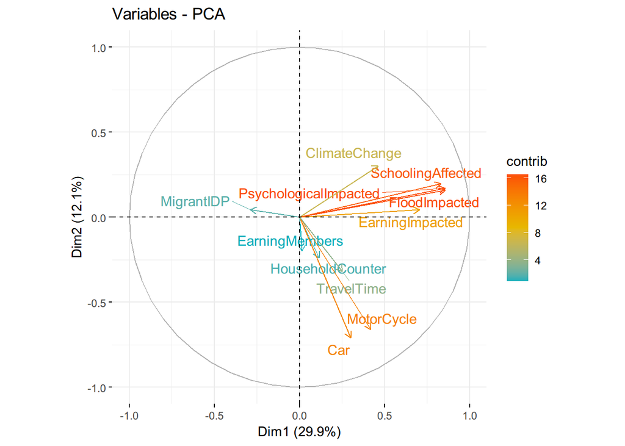

```r
#line below runs a simple PCA with a component for each variable.

viz_pca <- prcomp(scaled_aser_child_household_tib, center = TRUE,scale. = TRUE)

#Graph of variables. Positive correlated variables point to the same side of the plot. Negative correlated variables point to opposite sides of the graph.

fviz_pca_var(viz_pca,
             col.var = "contrib", # Color by contributions to the PC
             gradient.cols = c("#00AFBB", "#E7B800", "#FC4E07"),
             repel = TRUE #Avoid overlapping text if possible
             )
```

Through visualization, it seems that the following are loading together: **Dimension 1** (29.9%) and **Dimension 2** (12.1%)

1. **Climate Change Factors:** PsychologicalImpacted, SchoolingAffected, EarningImpacted, FloodImpacted, ClimateChange
2. **Household Factors:** MigrantIDP, HouseholdCounter, EarningMembers, Car, MotorCycle, TravelTime

## 5.8 STEP 4: Bartlett’s test

Bartlett’s test checks if the data is suitable for PCA by determining whether the variables are related enough (correlated) to find meaningful patterns.

```r
psych::cortest.bartlett(scaled_aser_child_household_tib, 2367) #there are 2367 observations
```

```
## R was not square, finding R from data
```

```
## $chisq
## [1] 6154.402
##
## $p.value
## [1] 0
##
## $df
## [1] 55
```

The p-value is very close to zero (it shows 0 in the result), so we reject the null hypothesis that the correlation matrix is an identity matrix, hence, PCA is justified because it will capture meaningful variance from the data.

## 5.9 STEP 5: KMO Test

The Kaiser-Meyer-Olkin (KMO) test tells you whether the data is good enough for PCA or factor analysis by checking how well the variables are grouped together. A KMO value of 0.5 or higher is considered suitable for PCA.

```r
psych::KMO(scaled_aser_child_household_tib)
```

```
## Kaiser-Meyer-Olkin factor adequacy
## Call: psych::KMO(r = scaled_aser_child_household_tib)
## Overall MSA =  0.81
## MSA for each item =
##      HouseholdCounter        EarningMembers                   Car
##                  0.69                  0.36                  0.65
##            MotorCycle            TravelTime         ClimateChange
##                  0.72                  0.75                  0.88
##         FloodImpacted       EarningImpacted PsychologicalImpacted
##                  0.81                  0.84                  0.81
##     SchoolingAffected            MigrantIDP
##                  0.83                  0.85
```

```r
#all data above .50 and overall MSA is strong (0.81) except for EarningMembers which is 0.36

# For reference: KMO > 0.8: Great for PCA! Variables are strongly related. KMO 0.7–0.8: Good, you can proceed. KMO 0.6–0.7: Okay, but be cautious. KMO < 0.6: Not ideal—your data might not be suitable for PCA.

# We are going to remove EarningMembers because it has a KMO of 0.36, which is below the suitable threshold of 0.5.

scaled_aser_child_household_tib <- scaled_aser_child_household_tib %>%
  select(-EarningMembers) #remove EarningMembers

KMO(scaled_aser_child_household_tib) #re-run KMO to make sure it is above .50, it is, hence, we can move on
```

```
## Kaiser-Meyer-Olkin factor adequacy
## Call: KMO(r = scaled_aser_child_household_tib)
## Overall MSA =  0.81
## MSA for each item =
##      HouseholdCounter                   Car            MotorCycle
##                  0.71                  0.65                  0.73
##            TravelTime         ClimateChange         FloodImpacted
##                  0.76                  0.88                  0.81
##       EarningImpacted PsychologicalImpacted     SchoolingAffected
##                  0.86                  0.81                  0.83
##            MigrantIDP
##                  0.85
```

Through the KMO test, we found that the variable *EarningMembers* is not suitable for PCA as it has a KMO value of 0.36, which is below the suitable threshold of 0.5. Hence, we removed it from the dataset.

## 5.10 STEP 6: Baseline PCA to select number of components

The baseline PCA is run to determine the number of components to keep in the final PCA analysis.

```r
#This is our initial PCA to see how many components we should keep.
pca_base <- principal(scaled_aser_child_household_tib, rotate = "none") #baseline PCA

pca_base
```

```
## Principal Components Analysis
## Call: principal(r = scaled_aser_child_household_tib, rotate = "none")
## Standardized loadings (pattern matrix) based upon correlation matrix
##                         PC1    h2   u2 com
## HouseholdCounter       0.11 0.013 0.99   1
## Car                    0.30 0.090 0.91   1
## MotorCycle             0.42 0.175 0.82   1
## TravelTime             0.25 0.063 0.94   1
## ClimateChange          0.46 0.214 0.79   1
## FloodImpacted          0.86 0.734 0.27   1
## EarningImpacted        0.71 0.498 0.50   1
## PsychologicalImpacted  0.86 0.734 0.27   1
## SchoolingAffected      0.83 0.688 0.31   1
## MigrantIDP            -0.29 0.083 0.92   1
##
##                 PC1
## SS loadings    3.29
## Proportion Var 0.33
##
## Mean item complexity =  1
## Test of the hypothesis that 1 component is sufficient.
##
## The root mean square of the residuals (RMSR) is  0.09
##  with the empirical chi square  1621.32  with prob <  9.999987e-319
##
## Fit based upon off diagonal values = 0.9
```

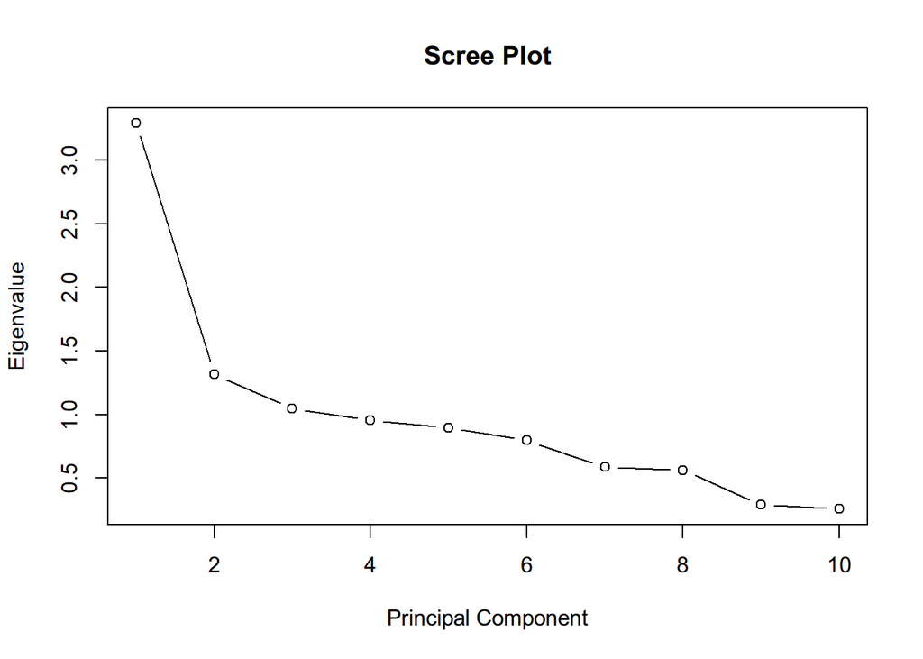

```r
plot(pca_base$values, type = "b", xlab = "Principal Component", ylab = "Eigenvalue", main = "Scree Plot") #type b means include both lines and points
```

```r
#the plot shows the variance explained by 2-3 linear components. We will keep 3 components for now.
```

## 5.11 STEP 7: Check that residuals are normally distributed

The residuals are checked to ensure that they are normally distributed.

```r
pca_resid <- principal(scaled_aser_child_household_tib, nfactors = 3 , rotate = "none")
pca_resid #results.
```

```
## Principal Components Analysis
## Call: principal(r = scaled_aser_child_household_tib, nfactors = 3,
##     rotate = "none")
## Standardized loadings (pattern matrix) based upon correlation matrix
##                         PC1   PC2   PC3   h2   u2 com
## HouseholdCounter       0.11  0.26  0.56 0.39 0.61 1.5
## Car                    0.30  0.73 -0.11 0.63 0.37 1.4
## MotorCycle             0.42  0.66 -0.17 0.64 0.36 1.9
## TravelTime             0.25  0.33  0.49 0.40 0.60 2.3
## ClimateChange          0.46 -0.29  0.40 0.45 0.55 2.7
## FloodImpacted          0.86 -0.16 -0.06 0.76 0.24 1.1
## EarningImpacted        0.71 -0.02  0.03 0.50 0.50 1.0
## PsychologicalImpacted  0.86 -0.18 -0.02 0.77 0.23 1.1
## SchoolingAffected      0.83 -0.21 -0.07 0.74 0.26 1.1
## MigrantIDP            -0.29 -0.04  0.54 0.37 0.63 1.5
##
##                        PC1  PC2  PC3
## SS loadings           3.29 1.32 1.05
## Proportion Var        0.33 0.13 0.10
## Cumulative Var        0.33 0.46 0.57
## Proportion Explained  0.58 0.23 0.19
## Cumulative Proportion 0.58 0.81 1.00
##
## Mean item complexity =  1.6
## Test of the hypothesis that 3 components are sufficient.
##
## The root mean square of the residuals (RMSR) is  0.11
##  with the empirical chi square  2484.85  with prob <  0
##
## Fit based upon off diagonal values = 0.85
```

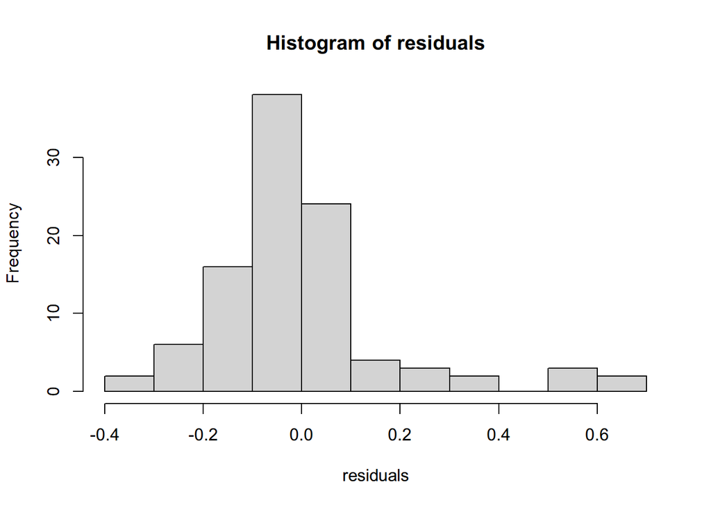

```r
#require correlation matrix for final data
corMatrix<-cor(scaled_aser_child_household_tib)

#next,create an object from the correlation matrix and the pca loading. Call it residuals. It will contain the factor residuals
residuals<-factor.residuals(corMatrix, pca_resid$loadings)

#call a histogram to check residuals
hist(residuals)
```

The residuals are somewhat normally distributed but exhibit positive skewness.